# HiFi Full-length 16S Analysis Report

## Summary QC statistics

- Samples number: 264
- Final samples number post-DADA2: 264
- Missing samples (Not enough reads, do not pass QC, etc):
- Total number of CCS reads before filtering and primers trimming: 13160690
- Was primers trimmed prior to DADA2? Yes
- Note that if downsampling was enabled, the reads will be filtered first, then restricted to a maximum of N reads.
- Total number of reads after quality filtering: 12891437 (97.95%)
- Total number of reads after primers trimming (DADA2 input): 12865685 (99.8%)
- Total number of ASVs found: 88
- Average number of ASVs per sample: 47
- Total number of reads in 88 ASVs: 9331109 (72.53% of all input reads)

### Classification using VSEARCH with a single database

- ASVs classified at Species level: 75 (85.23%)
- Percentage reads belong to ASV classified at Species level: 100%
- ASVs classified at Genus level: 75 (85.23%)
- Percentage reads belong to ASV classified at Genus level: 100%

### Classification using Naive Bayes classifier with SILVA, GTDB and RefSeq + RDP

- ASVs classified at Species level: 71 (80.68%)
- Percentage reads belong to ASV classified at Species level: 95%
- ASVs classified at Genus level: 83 (94.32%)
- Percentage reads belong to ASV classified at Genus level: 100%

## Overall reads filtering and number of full-length reads

- Full-length reads are defined as reads with both F27 and R1492 primers
- Note that full length counts column will only show if cutadapt was used to trim primers (default).

|  | Sample | Reads before quality filter | Reads after quality filter | Full-length Reads | Full-length Reads Percent |
| --- | --- | --- | --- | --- | --- |
| 1 | 16s_mas12_part_001 | 50000 | 49023 | 48923 | 0.9979601411582318 |
| 2 | 16s_mas12_part_002 | 50000 | 49154 | 49067 | 0.9982300524880986 |
| 3 | 16s_mas12_part_003 | 50000 | 48984 | 48884 | 0.9979585170667973 |
| 4 | 16s_mas12_part_004 | 50000 | 49075 | 48977 | 0.9980030565461029 |
| 5 | 16s_mas12_part_005 | 50000 | 49076 | 48985 | 0.9981457331485859 |
| 6 | 16s_mas12_part_006 | 50000 | 49018 | 48934 | 0.9982863437920764 |
| 7 | 16s_mas12_part_007 | 50000 | 49025 | 48941 | 0.9982865884752677 |
| 8 | 16s_mas12_part_008 | 50000 | 49105 | 49004 | 0.9979431829752571 |
| 9 | 16s_mas12_part_009 | 50000 | 49004 | 48881 | 0.9974900008162599 |
| 10 | 16s_mas12_part_010 | 50000 | 49130 | 49045 | 0.9982698961937716 |

[output cut: 254 more lines]

## Input reads QC (Before filtering and primers removal)

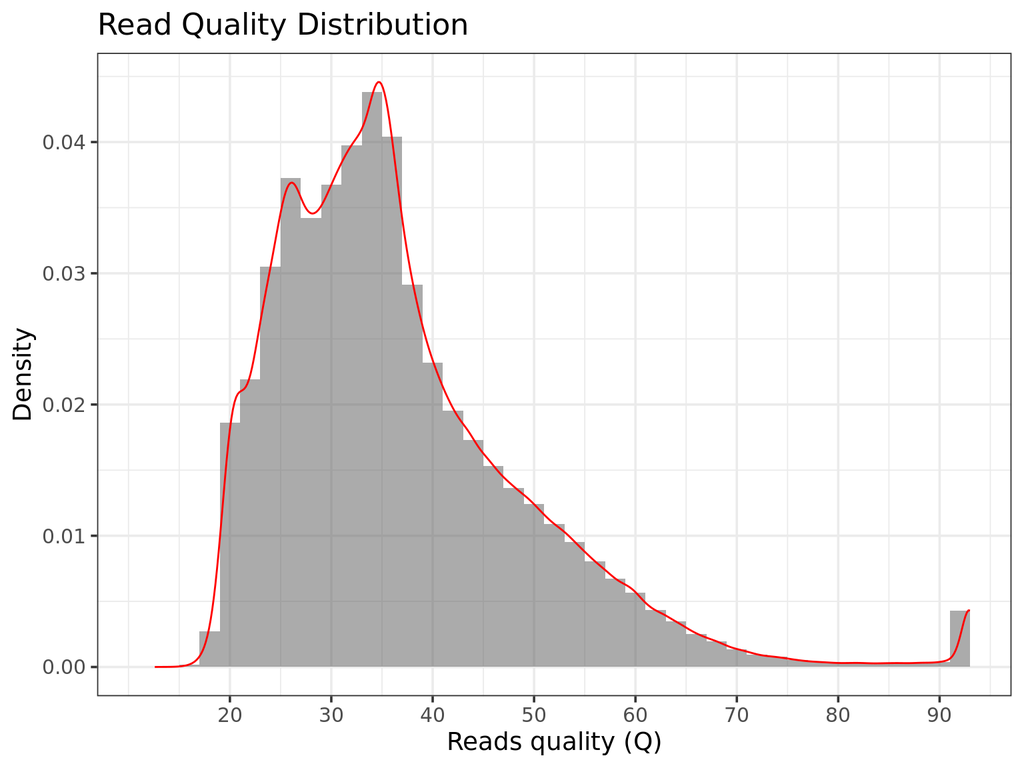

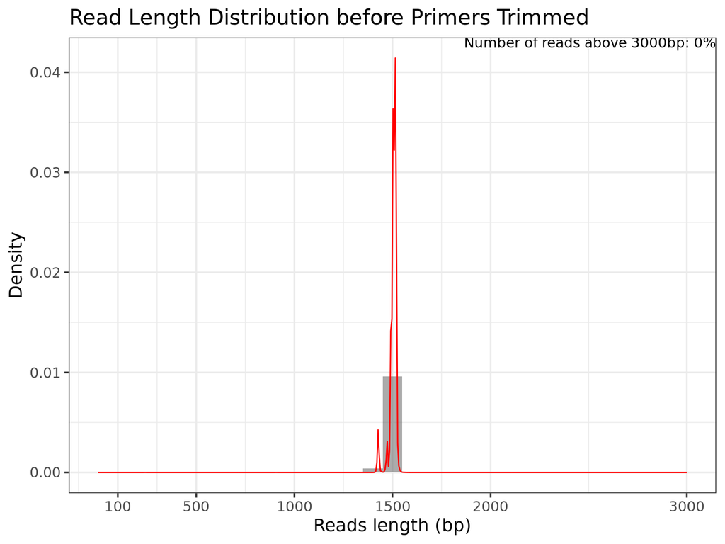

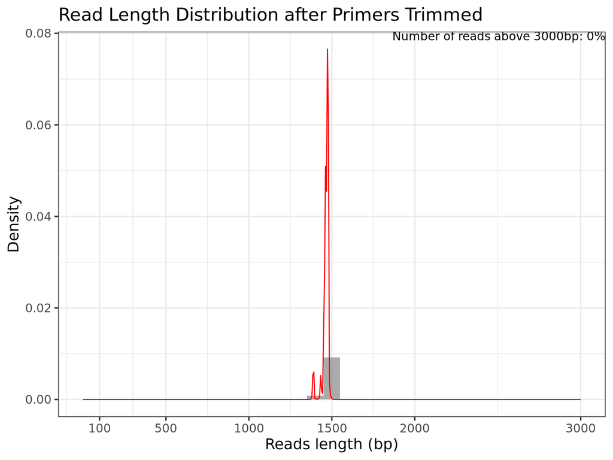

|  | Sample | Median Length (bp) | Median Read Quality | Length 1st Quartile (bp) | Length 3rd Quartile (bp) | Read Quality 1st Quartile (bp) | Read Quality 3rd Quartile (bp) |
| --- | --- | --- | --- | --- | --- | --- | --- |
| 1 | 16s_mas12_part_001 | 1509 | 34.61 | 1501 | 1514 | 28.24 | 42.69 |
| 2 | 16s_mas12_part_002 | 1510 | 34.67 | 1501 | 1514 | 28.42 | 42.84 |
| 3 | 16s_mas12_part_003 | 1509 | 34.65 | 1501 | 1514 | 28.38 | 42.77 |
| 4 | 16s_mas12_part_004 | 1509 | 34.73 | 1501 | 1514 | 28.28 | 43.19 |
| 5 | 16s_mas12_part_005 | 1509 | 34.64 | 1501 | 1514 | 28.32 | 42.92 |
| 6 | 16s_mas12_part_006 | 1510 | 34.55 | 1501 | 1514 | 28.32 | 42.76 |
| 7 | 16s_mas12_part_007 | 1510 | 34.64 | 1501 | 1515 | 28.27 | 43.01 |
| 8 | 16s_mas12_part_008 | 1510 | 34.81 | 1501 | 1514 | 28.4 | 43.39 |
| 9 | 16s_mas12_part_009 | 1509 | 34.67 | 1501 | 1514 | 28.35 | 43.12 |
| 10 | 16s_mas12_part_010 | 1509 | 34.69 | 1501 | 1514 | 28.36 | 43.11 |

[output cut: 254 more lines]

## DADA2 QC metrics

|  | sample-id | input | filtered | percentage of input passed filter | denoised | non-chimeric | percentage of input non-chimeric | n_ASV |
| --- | --- | --- | --- | --- | --- | --- | --- | --- |
| 1 | 16s_mas12_part_186 | 48814 | 35699 | 73.13 | 35261 | 35150 | 72.01 | 48 |
| 2 | 16s_mas12_part_157 | 48891 | 35596 | 72.81 | 35083 | 34999 | 71.59 | 47 |
| 3 | 16s_mas12_part_242 | 48782 | 36474 | 74.77 | 35962 | 35886 | 73.56 | 49 |
| 4 | 16s_mas12_part_135 | 48858 | 35841 | 73.36 | 35412 | 35285 | 72.22 | 47 |
| 5 | 16s_mas12_part_154 | 48947 | 35649 | 72.83 | 35108 | 35054 | 71.62 | 48 |
| 6 | 16s_mas12_part_172 | 48799 | 35334 | 72.41 | 34904 | 34785 | 71.28 | 48 |
| 7 | 16s_mas12_part_108 | 48822 | 35593 | 72.9 | 35110 | 35009 | 71.71 | 46 |
| 8 | 16s_mas12_part_238 | 48872 | 36440 | 74.56 | 35930 | 35884 | 73.42 | 46 |
| 9 | 16s_mas12_part_235 | 48887 | 36470 | 74.6 | 36005 | 35904 | 73.44 | 47 |
| 10 | 16s_mas12_part_226 | 48868 | 36152 | 73.98 | 35654 | 35575 | 72.8 | 46 |

[output cut: 254 more lines]

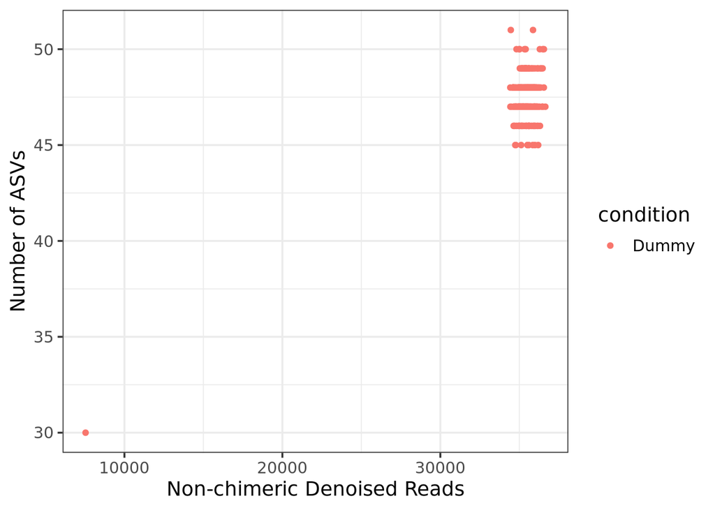

## Top Taxa and Plots

- For interactive view, use the Emperor QZV output from QIIME2 in `results/core-metrics-diversity` folder with QIIME2 View
- Note that if the distances between all samples are zero for a specific method, the plots will not be shown.
- MDS plots use ASVs as input.
- Samples might be missing due to choice of rarefecation depth. Rerun pipeline with `-resume --rarefaction_depth X` to choose a custom rarefaction depth X.

### Bray-Curtis MDS plot

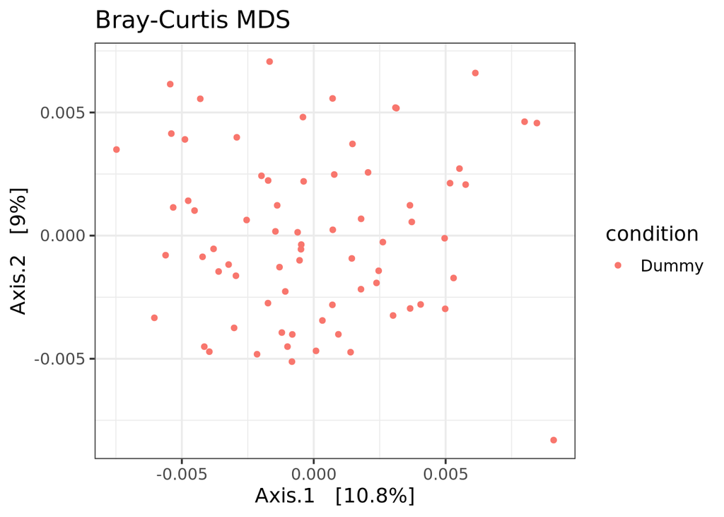

### Weighted and Unweighted Unifrac MDS plot

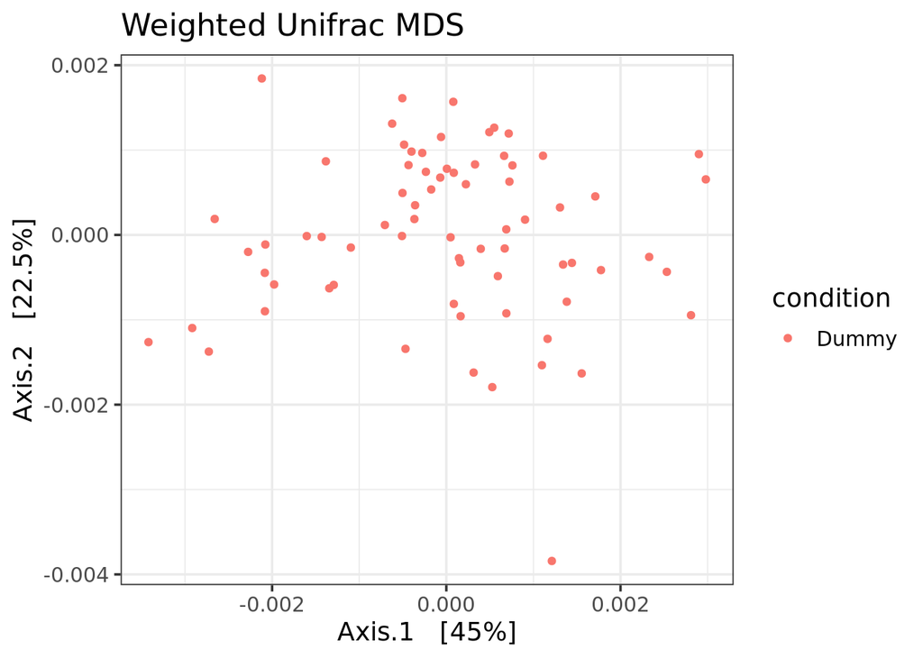

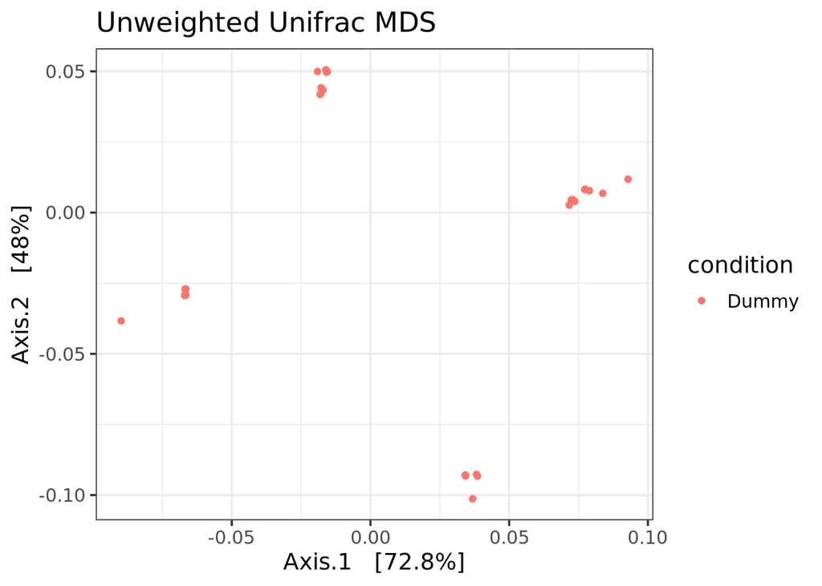

### Top 50 ASVs (VSEARCH classification)

|  | OTU | Kingdom | Phylum | Class | Order | Family | Genus | Species | 16s_mas12_part_100 | 16s_mas12_part_101 | 16s_mas12_part_102 | 16s_mas12_part_103 | 16s_mas12_part_104 | 16s_mas12_part_105 | 16s_mas12_part_106 | 16s_mas12_part_107 | 16s_mas12_part_108 | 16s_mas12_part_109 | 16s_mas12_part_010 | 16s_mas12_part_110 | 16s_mas12_part_111 | 16s_mas12_part_112 | 16s_mas12_part_113 | 16s_mas12_part_114 | 16s_mas12_part_115 | 16s_mas12_part_116 | 16s_mas12_part_117 | 16s_mas12_part_118 | 16s_mas12_part_119 | … |
| --- | --- | --- | --- | --- | --- | --- | --- | --- | --- | --- | --- | --- | --- | --- | --- | --- | --- | --- | --- | --- | --- | --- | --- | --- | --- | --- | --- | --- | --- | --- |
| 1 | 047702f9b44d31fdb62bce06b2cac9e0 | Unassigned |  |  |  |  |  |  | 0 | 0 | 0 | 0 | 0 | 0 | 0 | 0 | 0 | 0 | 0 | 0 | 0 | 0 | 0 | 0 | 0 | 0 | 0 | 0 | 0 | … |
| 2 | 07b2978940b50886f3866b04b7f982cf | Bacteria | Bacillota | Bacilli | Lactobacillales | Streptococcaceae | Streptococcus | Streptococcus agalactiae | 770 | 885 | 823 | 824 | 834 | 861 | 844 | 806 | 815 | 826 | 879 | 837 | 809 | 881 | 780 | 874 | 796 | 792 | 893 | 837 | 880 | … |
| 3 | 0bf3e0641c88ec588bc66b567c3fa63d | Bacteria | Pseudomonadota | Gammaproteobacteria | Enterobacterales | Enterobacteriaceae | Escherichia | Escherichia coli | 1309 | 1267 | 1239 | 1299 | 1281 | 1259 | 1203 | 1313 | 1275 | 1260 | 1304 | 1239 | 1298 | 1294 | 1247 | 1316 | 1278 | 1224 | 1299 | 1306 | 1325 | … |
| 4 | 0ed2d53fd823b2ef922b6f349cade1cd | Bacteria | Pseudomonadota | Gammaproteobacteria | Burkholderiales | Neisseriaceae | Neisseria | Neisseria meningitidis | 71 | 83 | 77 | 72 | 76 | 88 | 60 | 79 | 70 | 66 | 75 | 69 | 73 | 82 | 77 | 100 | 84 | 88 | 67 | 87 | 76 | … |
| 5 | 10cb90d33181cfa745c214b990e76bcb | Bacteria | Bacillota | Bacilli | Lactobacillales | Streptococcaceae | Streptococcus | Streptococcus pneumoniae | 0 | 0 | 0 | 0 | 0 | 0 | 0 | 0 | 0 | 0 | 0 | 0 | 0 | 0 | 0 | 0 | 0 | 0 | 0 | 0 | 0 | … |
| 6 | 13bc41e35faa4f40a01de5a972c0c4ac | Bacteria | Pseudomonadota | Gammaproteobacteria | Enterobacterales | Enterobacteriaceae | Escherichia | Escherichia coli | 2601 | 2636 | 2568 | 2643 | 2657 | 2549 | 2552 | 2602 | 2589 | 2631 | 2624 | 2565 | 2458 | 2593 | 2659 | 2592 | 2684 | 2469 | 2571 | 2700 | 2613 | … |
| 7 | 27be187284317979c93fd2218ee3722e | Bacteria | Bacillota | Bacilli | Staphylococcales | Staphylococcaceae | Staphylococcus | Staphylococcus aureus | 163 | 155 | 171 | 154 | 142 | 129 | 169 | 167 | 152 | 161 | 184 | 169 | 194 | 205 | 148 | 140 | 239 | 131 | 151 | 142 | 141 | … |
| 8 | 28942fb2b2070c5992fe7b5c635a63d5 | Unassigned |  |  |  |  |  |  | 0 | 0 | 0 | 0 | 0 | 0 | 0 | 0 | 0 | 0 | 0 | 0 | 0 | 0 | 0 | 0 | 0 | 0 | 0 | 0 | 0 | … |
| 9 | 339aac7377a0d948a52bc0b2bf3dfda8 | Bacteria | Bacteroidota | Bacteroidia | Bacteroidales | Bacteroidaceae | Phocaeicola | Phocaeicola vulgatus | 9 | 0 | 0 | 0 | 0 | 0 | 0 | 0 | 0 | 7 | 0 | 0 | 0 | 6 | 0 | 0 | 0 | 0 | 0 | 0 | 0 | … |
| 10 | 34b695df3f78278d604299f2c4adc80c | Bacteria | Deinococcota | Deinococci | Deinococcales | Deinococcaceae | Deinococcus | Deinococcus radiodurans | 0 | 0 | 0 | 0 | 0 | 0 | 0 | 0 | 0 | 0 | 7 | 0 | 0 | 0 | 0 | 6 | 5 | 8 | 0 | 0 | 0 | … |

[output cut: 40 more lines]

### Top 10 Classified Genus (Collapsed to species) with VSEARCH

- Relative abundance is calculated by dividing the number of reads for each ASV to the total number of reads in each sample.
- Heatmap contains only species with >1% abundance in at least 2 samples for the top 10 genus.

|  | Genus | Mean supporting reads across samples | Mean relative abundance across samples |
| --- | --- | --- | --- |
| 1 | Streptococcus | 9551.48 | 0.27 |
| 2 | Escherichia | 8999 | 0.25 |
| 3 | Staphylococcus | 7210.56 | 0.2 |
| 4 | Porphyromonas | 4258.27 | 0.12 |
| 5 | Bacillus A | 2288.52 | 0.06 |
| 6 | Cereibacter A | 1453.87 | 0.04 |
| 7 | Clostridium | 919.24 | 0.03 |
| 8 | Pseudomonas | 343.87 | 0.01 |
| 9 | Acinetobacter | 93.35 | 0 |
| 10 | Bifidobacterium | 0.04 | 0 |

[output cut: 8 more lines]

|  | Genus | Species | 16s_mas12_part_100 | 16s_mas12_part_101 | 16s_mas12_part_102 | 16s_mas12_part_103 | 16s_mas12_part_104 | 16s_mas12_part_105 | 16s_mas12_part_106 | 16s_mas12_part_107 | 16s_mas12_part_108 | 16s_mas12_part_109 | 16s_mas12_part_010 | 16s_mas12_part_110 | 16s_mas12_part_111 | 16s_mas12_part_112 | 16s_mas12_part_113 | 16s_mas12_part_114 | 16s_mas12_part_115 | 16s_mas12_part_116 | 16s_mas12_part_117 | 16s_mas12_part_118 | 16s_mas12_part_119 | 16s_mas12_part_011 | 16s_mas12_part_120 | 16s_mas12_part_121 | 16s_mas12_part_122 | 16s_mas12_part_123 | 16s_mas12_part_124 | … |
| --- | --- | --- | --- | --- | --- | --- | --- | --- | --- | --- | --- | --- | --- | --- | --- | --- | --- | --- | --- | --- | --- | --- | --- | --- | --- | --- | --- | --- | --- | --- |
| 1 | Streptococcus | Streptococcus agalactiae | 770 | 885 | 823 | 824 | 834 | 861 | 844 | 806 | 815 | 826 | 879 | 837 | 809 | 881 | 780 | 874 | 796 | 792 | 893 | 837 | 880 | 889 | 809 | 838 | 839 | 885 | 868 | … |
| 2 | Streptococcus | Streptococcus mutans | 8486 | 8611 | 8603 | 8609 | 8720 | 8769 | 8424 | 8576 | 8617 | 8805 | 8839 | 8682 | 8569 | 8736 | 8574 | 8656 | 8600 | 8694 | 8744 | 8816 | 8508 | 8775 | 8752 | 8566 | 8481 | 8603 | 8463 | … |
| 3 | Streptococcus | Streptococcus pneumoniae | 0 | 0 | 0 | 0 | 0 | 0 | 0 | 0 | 0 | 0 | 0 | 0 | 0 | 0 | 0 | 0 | 0 | 0 | 0 | 0 | 0 | 0 | 0 | 0 | 0 | 0 | 0 | … |
| 4 | Escherichia | Escherichia coli | 8870 | 8915 | 8919 | 9008 | 9013 | 8863 | 8705 | 8947 | 8969 | 8924 | 9276 | 8879 | 8788 | 8889 | 8933 | 9057 | 9025 | 8722 | 8906 | 9218 | 8978 | 9043 | 8900 | 8885 | 8842 | 8667 | 8913 | … |
| 5 | Staphylococcus | Staphylococcus aureus | 492 | 506 | 489 | 464 | 459 | 460 | 472 | 464 | 464 | 501 | 502 | 505 | 455 | 432 | 435 | 464 | 460 | 474 | 478 | 480 | 447 | 491 | 508 | 474 | 462 | 518 | 447 | … |
| 6 | Staphylococcus | Staphylococcus epidermidis | 6684 | 6669 | 6559 | 6599 | 6592 | 6813 | 6561 | 6603 | 6656 | 6615 | 6845 | 6697 | 6718 | 6697 | 6658 | 6766 | 6598 | 6758 | 6782 | 6593 | 6550 | 6866 | 6612 | 6549 | 6624 | 6604 | 6703 | … |
| 7 | Porphyromonas | Porphyromonas gingivalis | 4189 | 4210 | 4299 | 4194 | 4242 | 4194 | 4154 | 4087 | 4180 | 4193 | 4396 | 4229 | 4222 | 4201 | 4222 | 4213 | 4245 | 4211 | 4381 | 4291 | 4111 | 4345 | 4165 | 4172 | 4269 | 4353 | 4272 | … |
| 8 | Bacillus A | Bacillus A pacificus | 2291 | 2299 | 2309 | 2320 | 2300 | 2304 | 2290 | 2217 | 2255 | 2143 | 2391 | 2208 | 2211 | 2323 | 2355 | 2308 | 2238 | 2258 | 2286 | 2276 | 2294 | 2332 | 2255 | 2197 | 2286 | 2247 | 2191 | … |
| 9 | Bacillus A | Bacillus A tropicus | 0 | 0 | 0 | 0 | 0 | 0 | 0 | 0 | 0 | 0 | 0 | 0 | 0 | 0 | 0 | 0 | 0 | 0 | 0 | 0 | 0 | 0 | 0 | 0 | 0 | 0 | 0 | … |
| 10 | Cereibacter A | Cereibacter A sphaeroides | 1411 | 1457 | 1497 | 1391 | 1481 | 1497 | 1406 | 1398 | 1489 | 1473 | 1517 | 1413 | 1484 | 1481 | 1447 | 1399 | 1476 | 1459 | 1434 | 1481 | 1447 | 1454 | 1372 | 1354 | 1418 | 1415 | 1502 | … |

[output cut: 12 more lines]

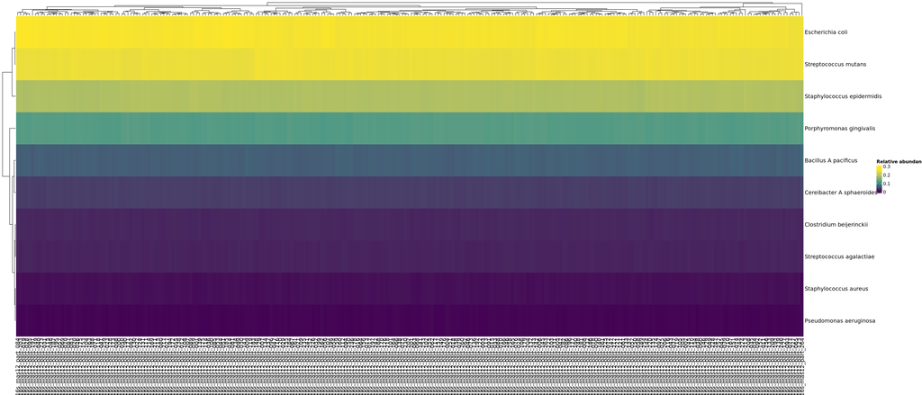

### Top 50 ASVs (Naive Bayes Classifier)

|  | OTU | Kingdom | Phylum | Class | Order | Family | Genus | Species | 16s_mas12_part_100 | 16s_mas12_part_101 | 16s_mas12_part_102 | 16s_mas12_part_103 | 16s_mas12_part_104 | 16s_mas12_part_105 | 16s_mas12_part_106 | 16s_mas12_part_107 | 16s_mas12_part_108 | 16s_mas12_part_109 | 16s_mas12_part_010 | 16s_mas12_part_110 | 16s_mas12_part_111 | 16s_mas12_part_112 | 16s_mas12_part_113 | 16s_mas12_part_114 | 16s_mas12_part_115 | 16s_mas12_part_116 | 16s_mas12_part_117 | 16s_mas12_part_118 | 16s_mas12_part_119 | … |
| --- | --- | --- | --- | --- | --- | --- | --- | --- | --- | --- | --- | --- | --- | --- | --- | --- | --- | --- | --- | --- | --- | --- | --- | --- | --- | --- | --- | --- | --- | --- |
| 1 | 047702f9b44d31fdb62bce06b2cac9e0 | Bacteria | Bacillota I | Bacilli A | Lactobacillales | Streptococcaceae | Streptococcus | Streptococcus mutans | 0 | 0 | 0 | 0 | 0 | 0 | 0 | 0 | 0 | 0 | 0 | 0 | 0 | 0 | 0 | 0 | 0 | 0 | 0 | 0 | 0 | … |
| 2 | 07b2978940b50886f3866b04b7f982cf | Bacteria | Bacillota I | Bacilli A | Lactobacillales | Streptococcaceae | Streptococcus | Streptococcus agalactiae | 770 | 885 | 823 | 824 | 834 | 861 | 844 | 806 | 815 | 826 | 879 | 837 | 809 | 881 | 780 | 874 | 796 | 792 | 893 | 837 | 880 | … |
| 3 | 0bf3e0641c88ec588bc66b567c3fa63d | Bacteria | Pseudomonadota | Gammaproteobacteria | Enterobacterales | Enterobacteriaceae | Escherichia-Shigella | Escherichia-Shigella coli | 1309 | 1267 | 1239 | 1299 | 1281 | 1259 | 1203 | 1313 | 1275 | 1260 | 1304 | 1239 | 1298 | 1294 | 1247 | 1316 | 1278 | 1224 | 1299 | 1306 | 1325 | … |
| 4 | 0ed2d53fd823b2ef922b6f349cade1cd | Bacteria | Pseudomonadota | Gammaproteobacteria | Burkholderiales | Neisseriaceae | Neisseria 563205 | Neisseria 563205 meningitidis | 71 | 83 | 77 | 72 | 76 | 88 | 60 | 79 | 70 | 66 | 75 | 69 | 73 | 82 | 77 | 100 | 84 | 88 | 67 | 87 | 76 | … |
| 5 | 10cb90d33181cfa745c214b990e76bcb | Bacteria | Bacillota | Bacilli | Bacillales | Bacillaceae | Bacillus | Unclassified | 0 | 0 | 0 | 0 | 0 | 0 | 0 | 0 | 0 | 0 | 0 | 0 | 0 | 0 | 0 | 0 | 0 | 0 | 0 | 0 | 0 | … |
| 6 | 13bc41e35faa4f40a01de5a972c0c4ac | Bacteria | Pseudomonadota | Gammaproteobacteria | Enterobacterales | Enterobacteriaceae | Escherichia-Shigella | Escherichia-Shigella coli | 2601 | 2636 | 2568 | 2643 | 2657 | 2549 | 2552 | 2602 | 2589 | 2631 | 2624 | 2565 | 2458 | 2593 | 2659 | 2592 | 2684 | 2469 | 2571 | 2700 | 2613 | … |
| 7 | 27be187284317979c93fd2218ee3722e | Bacteria | Bacillota | Bacilli | Staphylococcales | Staphylococcaceae | Staphylococcus | Staphylococcus aureus | 163 | 155 | 171 | 154 | 142 | 129 | 169 | 167 | 152 | 161 | 184 | 169 | 194 | 205 | 148 | 140 | 239 | 131 | 151 | 142 | 141 | … |
| 8 | 28942fb2b2070c5992fe7b5c635a63d5 | Bacteria | Bacillota | Bacilli | Staphylococcales | Staphylococcaceae | Staphylococcus | Unclassified | 0 | 0 | 0 | 0 | 0 | 0 | 0 | 0 | 0 | 0 | 0 | 0 | 0 | 0 | 0 | 0 | 0 | 0 | 0 | 0 | 0 | … |
| 9 | 339aac7377a0d948a52bc0b2bf3dfda8 | Bacteria | Bacteroidota | Bacteroidia | Bacteroidales | Bacteroidaceae | Phocaeicola A | Phocaeicola A vulgatus | 9 | 0 | 0 | 0 | 0 | 0 | 0 | 0 | 0 | 7 | 0 | 0 | 0 | 6 | 0 | 0 | 0 | 0 | 0 | 0 | 0 | … |
| 10 | 34b695df3f78278d604299f2c4adc80c | Bacteria | Deinococcota | Deinococci | Deinococcales | Deinococcaceae | Deinococcus B | Deinococcus B radiodurans | 0 | 0 | 0 | 0 | 0 | 0 | 0 | 0 | 0 | 0 | 7 | 0 | 0 | 0 | 0 | 6 | 5 | 8 | 0 | 0 | 0 | … |

[output cut: 40 more lines]

### Top 10 Classified Genus (Collapsed to species) with Naive Bayes Classifier

- Relative abundance is calculated by dividing the number of reads for each ASV to the total number of reads in each sample.
- Heatmap contains only species with >1% abundance in at least 2 samples for the top 10 genus.

|  | Genus | Mean supporting reads across samples | Mean relative abundance across samples |
| --- | --- | --- | --- |
| 1 | Streptococcus | 9552.31 | 0.27 |
| 2 | Staphylococcus | 7210.76 | 0.2 |
| 3 | Escherichia-Shigella | 5210.95 | 0.15 |
| 4 | Porphyromonas A | 4258.27 | 0.12 |
| 5 | Escherichia | 2512.87 | 0.07 |
| 6 | Bacillus | 2288.74 | 0.06 |
| 7 | Cereibacter A 494292 | 1453.87 | 0.04 |
| 8 | Collinsella | 1275.18 | 0.04 |
| 9 | Clostridium T | 919.24 | 0.03 |
| 10 | Pseudomonas | 343.87 | 0.01 |

|  | Genus | Species | 16s_mas12_part_100 | 16s_mas12_part_101 | 16s_mas12_part_102 | 16s_mas12_part_103 | 16s_mas12_part_104 | 16s_mas12_part_105 | 16s_mas12_part_106 | 16s_mas12_part_107 | 16s_mas12_part_108 | 16s_mas12_part_109 | 16s_mas12_part_010 | 16s_mas12_part_110 | 16s_mas12_part_111 | 16s_mas12_part_112 | 16s_mas12_part_113 | 16s_mas12_part_114 | 16s_mas12_part_115 | 16s_mas12_part_116 | 16s_mas12_part_117 | 16s_mas12_part_118 | 16s_mas12_part_119 | 16s_mas12_part_011 | 16s_mas12_part_120 | 16s_mas12_part_121 | 16s_mas12_part_122 | 16s_mas12_part_123 | 16s_mas12_part_124 | … |
| --- | --- | --- | --- | --- | --- | --- | --- | --- | --- | --- | --- | --- | --- | --- | --- | --- | --- | --- | --- | --- | --- | --- | --- | --- | --- | --- | --- | --- | --- | --- |
| 1 | Streptococcus | Streptococcus agalactiae | 770 | 885 | 823 | 824 | 834 | 861 | 844 | 806 | 815 | 826 | 879 | 837 | 809 | 881 | 780 | 874 | 796 | 792 | 893 | 837 | 880 | 889 | 809 | 838 | 839 | 885 | 868 | … |
| 2 | Streptococcus | Streptococcus mutans | 8486 | 8611 | 8603 | 8609 | 8720 | 8769 | 8424 | 8583 | 8617 | 8805 | 8839 | 8682 | 8569 | 8736 | 8574 | 8656 | 8600 | 8701 | 8744 | 8816 | 8508 | 8775 | 8752 | 8566 | 8486 | 8603 | 8463 | … |
| 3 | Staphylococcus | Staphylococcus aureus | 492 | 506 | 489 | 464 | 459 | 460 | 472 | 464 | 464 | 501 | 502 | 505 | 455 | 432 | 435 | 464 | 460 | 474 | 478 | 480 | 447 | 491 | 508 | 474 | 462 | 518 | 447 | … |
| 4 | Staphylococcus | Staphylococcus caprae | 0 | 0 | 0 | 0 | 0 | 0 | 0 | 0 | 0 | 0 | 0 | 0 | 0 | 0 | 0 | 0 | 0 | 0 | 0 | 0 | 0 | 0 | 0 | 0 | 0 | 0 | 0 | … |
| 5 | Staphylococcus | Staphylococcus epidermidis | 6684 | 6669 | 6559 | 6599 | 6592 | 6813 | 6561 | 6603 | 6656 | 6615 | 6845 | 6697 | 6718 | 6697 | 6658 | 6766 | 6598 | 6758 | 6782 | 6593 | 6550 | 6866 | 6612 | 6549 | 6624 | 6604 | 6703 | … |
| 6 | Staphylococcus | Staphylococcus saccharolyticus | 0 | 0 | 0 | 0 | 0 | 0 | 0 | 0 | 0 | 0 | 0 | 0 | 0 | 0 | 0 | 0 | 0 | 0 | 0 | 0 | 0 | 0 | 0 | 0 | 0 | 0 | 0 | … |
| 7 | Staphylococcus | Unclassified | 0 | 0 | 0 | 0 | 0 | 0 | 0 | 0 | 0 | 0 | 0 | 0 | 0 | 0 | 0 | 0 | 0 | 0 | 0 | 0 | 0 | 0 | 0 | 0 | 0 | 0 | 0 | … |
| 8 | Escherichia-Shigella | Escherichia-Shigella coli | 3910 | 3903 | 3807 | 3942 | 3938 | 3808 | 3755 | 3915 | 3864 | 3891 | 3928 | 3804 | 3756 | 3887 | 3906 | 3908 | 3962 | 3693 | 3870 | 4006 | 3938 | 3878 | 3935 | 3871 | 3908 | 3793 | 3761 | … |
| 9 | Escherichia-Shigella | Unclassified | 1287 | 1275 | 1251 | 1285 | 1345 | 1223 | 1344 | 1231 | 1253 | 1273 | 1421 | 1272 | 1251 | 1239 | 1284 | 1301 | 1340 | 1322 | 1298 | 1366 | 1273 | 1352 | 1288 | 1292 | 1263 | 1286 | 1321 | … |
| 10 | Porphyromonas A | Porphyromonas A gingivalis | 4189 | 4210 | 4299 | 4194 | 4242 | 4194 | 4154 | 4087 | 4180 | 4193 | 4396 | 4229 | 4222 | 4201 | 4222 | 4213 | 4245 | 4211 | 4381 | 4291 | 4111 | 4345 | 4165 | 4172 | 4269 | 4353 | 4272 | … |

[output cut: 8 more lines]

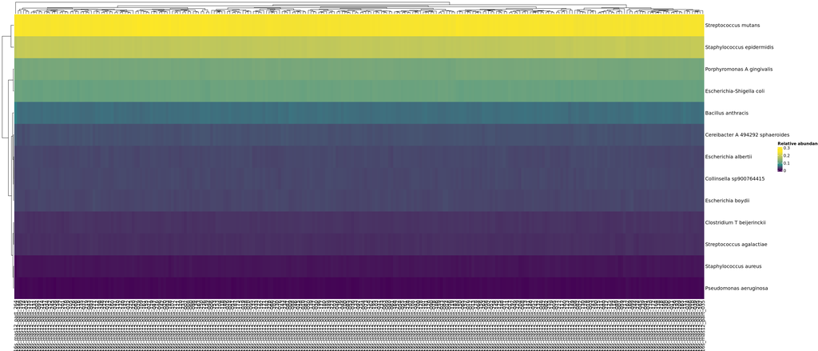